# Chapter 6 Assignment

Joe Dickerson

2025-09-28

Problem 8.

```r
set.seed(1)

x <- rnorm(100)
e <- rnorm(100)
```

```r
B0 <- 2
B1 <- -6
B2 <- 5
B3 <- -1

Y <- B0 + B1*x + B2*x^2 + B3*x^3 + e
```

Per the plots and checking the min and max values, for bic the model is best fit with 3 variables, with cp it is 4 variables, and with adjr2 it is 4 variables. The plots verify this visually.

```r
data <- data.frame(I(x), I(x^2), I(x^3), I(x^4), I(x^5), I(x^6), I(x^7), I(x^8), I(x^9), I(x^10), Y)
regfit.full <- regsubsets(Y ~ ., data = data, nvmax = 10)
reg.summary <- summary(regfit.full)

which.min(reg.summary$bic)
```

```
## [1] 3
```

```r
which.min(reg.summary$cp)
```

```
## [1] 4
```

```r
which.max(reg.summary$adjr2)
```

```
## [1] 4
```

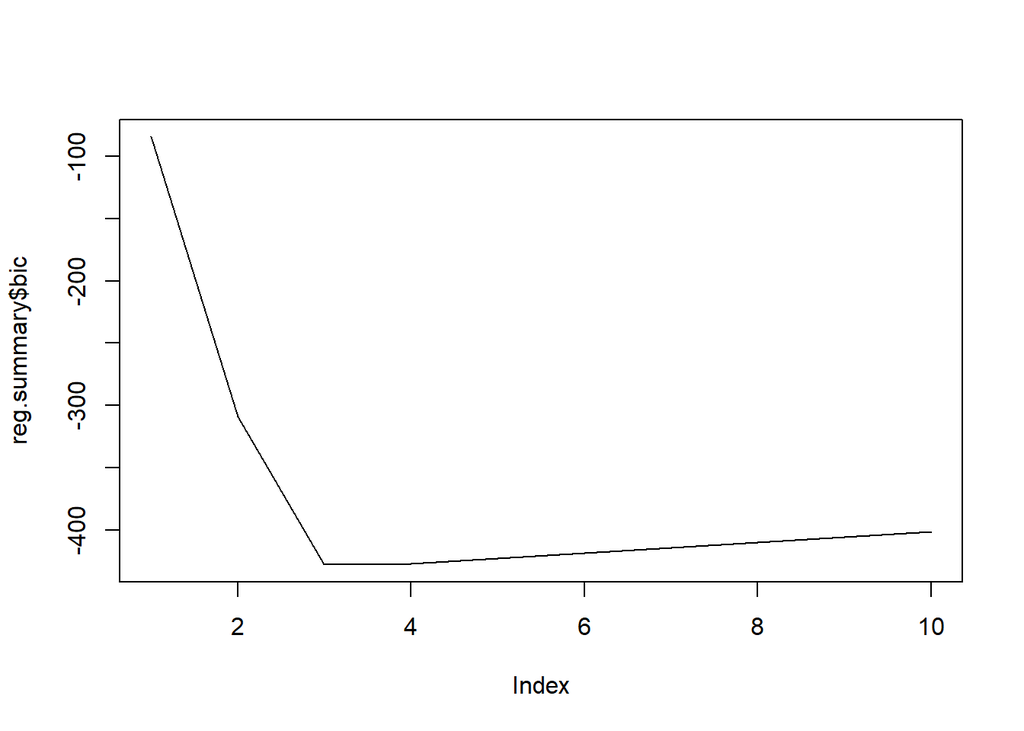

```r
plot(reg.summary$bic, type = "l")
```

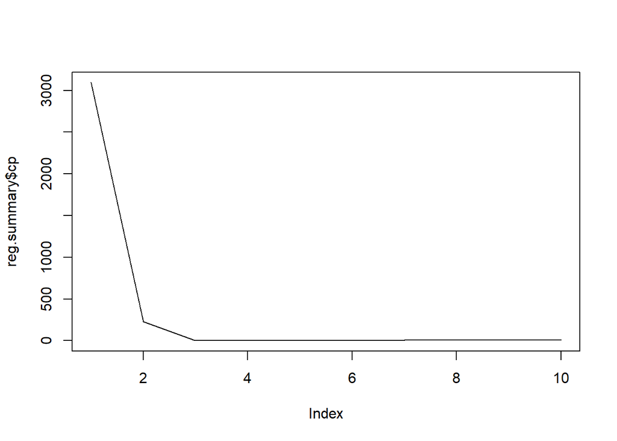

```r
plot(reg.summary$cp, type = "l")
```

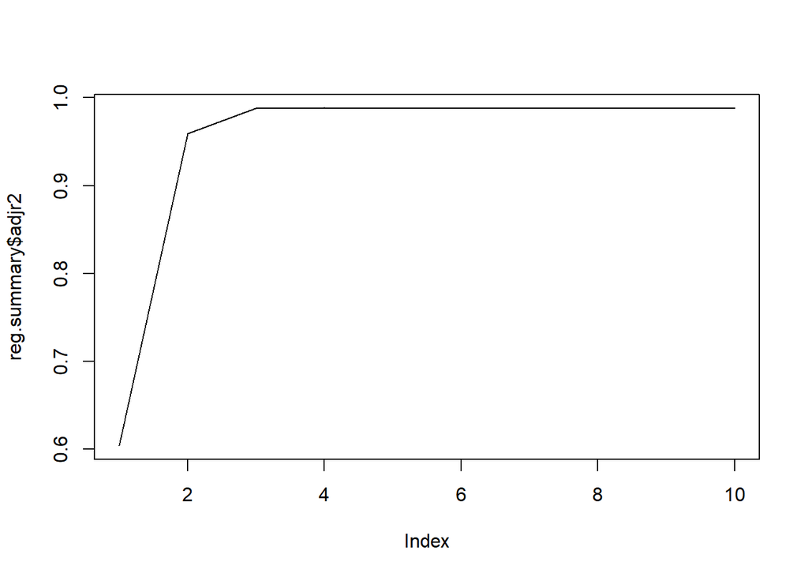

```r
plot(reg.summary$adjr2, type = "l")
```

Using forward and backward stepwise selection we see similar results to c. Both methods suggest a model using only 3 variables, which does differ slightly from c. as we had a couple indications to use a model with 4 variables.

```r
regfit.fwd <- regsubsets(Y ~ ., data = data, nvmax = 10, method = "forward")
regfit.bwd <- regsubsets(Y ~ ., data = data, nvmax = 10, method = "backward")

summary(regfit.fwd)
```

```
## Subset selection object
## Call: regsubsets.formula(Y ~ ., data = data, nvmax = 10, method = "forward")
## 10 Variables  (and intercept)
##      Forced in Forced out
## x        FALSE      FALSE
## x.2      FALSE      FALSE
## x.3      FALSE      FALSE
## x.4      FALSE      FALSE
## x.5      FALSE      FALSE
## x.6      FALSE      FALSE
## x.7      FALSE      FALSE
## x.8      FALSE      FALSE
## x.9      FALSE      FALSE
## x.10     FALSE      FALSE
## 1 subsets of each size up to 10
## Selection Algorithm: forward
##           x   x.2 x.3 x.4 x.5 x.6 x.7 x.8 x.9 x.10
## 1  ( 1 )  "*" " " " " " " " " " " " " " " " " " "
## 2  ( 1 )  "*" "*" " " " " " " " " " " " " " " " "
## 3  ( 1 )  "*" "*" "*" " " " " " " " " " " " " " "
## 4  ( 1 )  "*" "*" "*" " " "*" " " " " " " " " " "
## 5  ( 1 )  "*" "*" "*" " " "*" "*" " " " " " " " "
## 6  ( 1 )  "*" "*" "*" " " "*" "*" " " " " "*" " "
## 7  ( 1 )  "*" "*" "*" " " "*" "*" "*" " " "*" " "
## 8  ( 1 )  "*" "*" "*" " " "*" "*" "*" "*" "*" " "
## 9  ( 1 )  "*" "*" "*" " " "*" "*" "*" "*" "*" "*"
## 10  ( 1 ) "*" "*" "*" "*" "*" "*" "*" "*" "*" "*"
```

```r
summary(regfit.bwd)
```

```
## Subset selection object
## Call: regsubsets.formula(Y ~ ., data = data, nvmax = 10, method = "backward")
## 10 Variables  (and intercept)
##      Forced in Forced out
## x        FALSE      FALSE
## x.2      FALSE      FALSE
## x.3      FALSE      FALSE
## x.4      FALSE      FALSE
## x.5      FALSE      FALSE
## x.6      FALSE      FALSE
## x.7      FALSE      FALSE
## x.8      FALSE      FALSE
## x.9      FALSE      FALSE
## x.10     FALSE      FALSE
## 1 subsets of each size up to 10
## Selection Algorithm: backward
##           x   x.2 x.3 x.4 x.5 x.6 x.7 x.8 x.9 x.10
## 1  ( 1 )  "*" " " " " " " " " " " " " " " " " " "
## 2  ( 1 )  "*" "*" " " " " " " " " " " " " " " " "
## 3  ( 1 )  "*" "*" "*" " " " " " " " " " " " " " "
## 4  ( 1 )  "*" "*" "*" " " " " " " " " " " "*" " "
## 5  ( 1 )  "*" "*" "*" " " " " " " " " "*" "*" " "
## 6  ( 1 )  "*" "*" "*" " " " " " " " " "*" "*" "*"
## 7  ( 1 )  "*" "*" "*" " " " " "*" " " "*" "*" "*"
## 8  ( 1 )  "*" "*" "*" "*" " " "*" " " "*" "*" "*"
## 9  ( 1 )  "*" "*" "*" "*" "*" "*" " " "*" "*" "*"
## 10  ( 1 ) "*" "*" "*" "*" "*" "*" "*" "*" "*" "*"
```

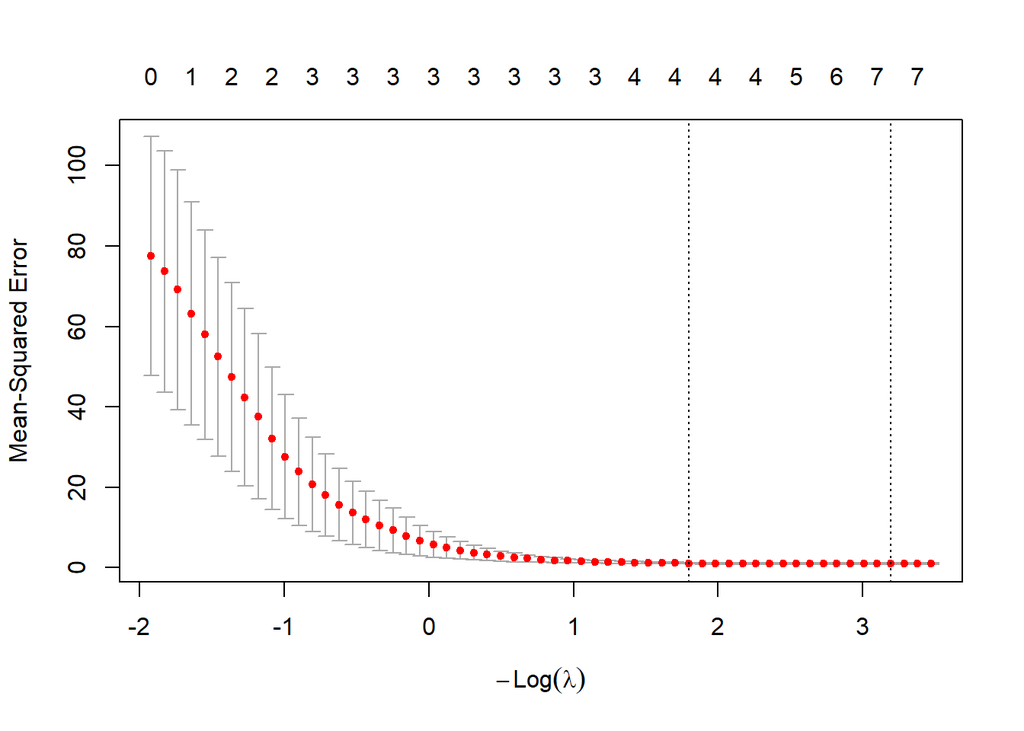

```r
x <- model.matrix(Y ~ ., data)[,-1]
y <- data$Y

train <- sample(1:nrow(x), nrow(x) / 2)
test <- (-train)
y.test <- y[test]


cv.out <- cv.glmnet(x, y, alpha = 1)

plot(cv.out)
```

```r
bestlam <- cv.out$lambda.min
bestlam
```

```
## [1] 0.04099418
```

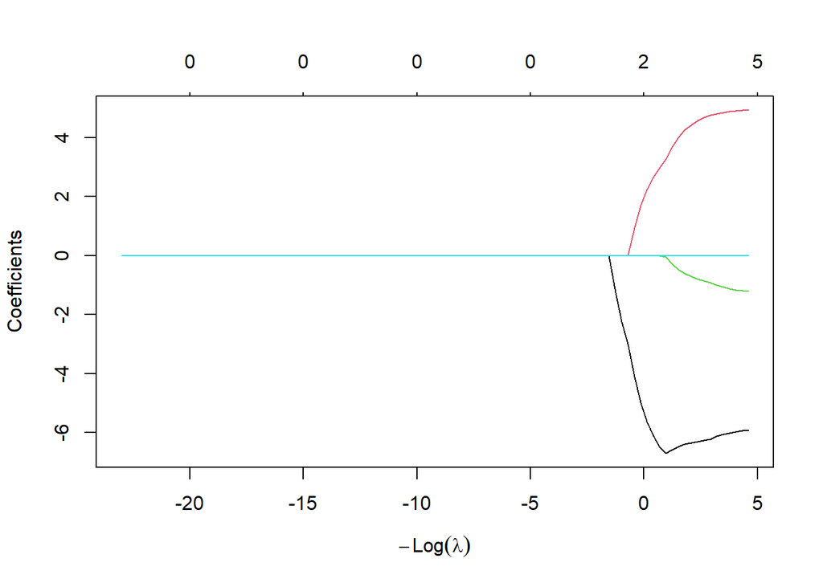

```r
grid <- 10^seq(10, -2, length = 100)

lasso.mod <- glmnet(x[train, ], y[train], alpha = 1, lambda = grid)
plot(lasso.mod)
```

```r
lasso.coef <- predict(lasso.mod, type = "coefficients", s = bestlam)[1:11,]

lasso.coef
```

```
##   (Intercept)             x           x.2           x.3           x.4
##  2.0245324098 -6.1327914081  4.8141087486 -0.9962447001  0.0000000000
##           x.5           x.6           x.7           x.8           x.9
##  0.0000000000  0.0000000000  0.0000000000  0.0000000000  0.0000000000
##          x.10
##  0.0003516795
```

B7 is equal to 11. We now have ideal variables of 1 or 2 when checking the cp and bic as we had done previously, 1 for bic and 2 for cp. The Lasso model chooses a single variable when checking the coefficients, and the coefficient for B7 (10.68) is very similar to our actual B7 (11). It seems Lasso is the better model among what is tested here.

```r
set.seed(1)

x <- rnorm(100)
e <- rnorm(100)

B7 <- 11
Y2 <- B0 + B7*x^7 + e
data2 <- data.frame(x, x^2, x^3, x^4, x^5, x^6, x^7, x^8, x^9, x^10, Y2)

regfit.full2 <- regsubsets(Y2 ~ ., data = data2, nvmax = 10)
reg.summary2 <- summary(regfit.full2)

which.min(reg.summary2$bic)
```

```
## [1] 1
```

```r
which.min(reg.summary2$cp)
```

```
## [1] 2
```

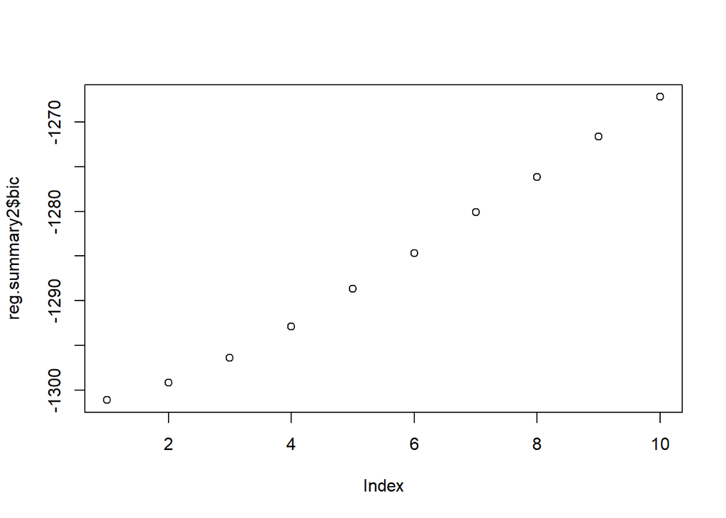

```r
plot(reg.summary2$bic)
```

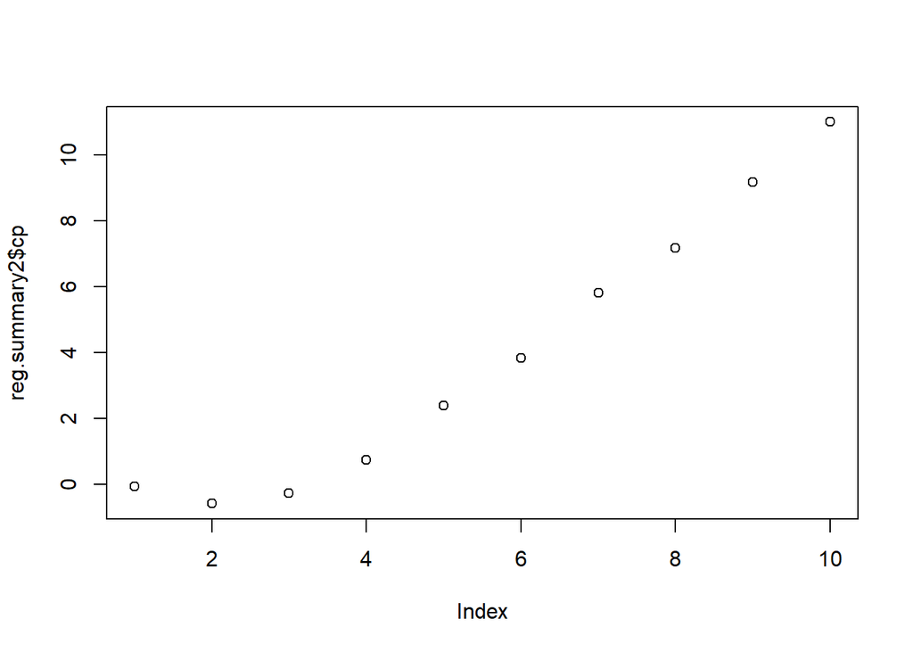

```r
plot(reg.summary2$cp)
```

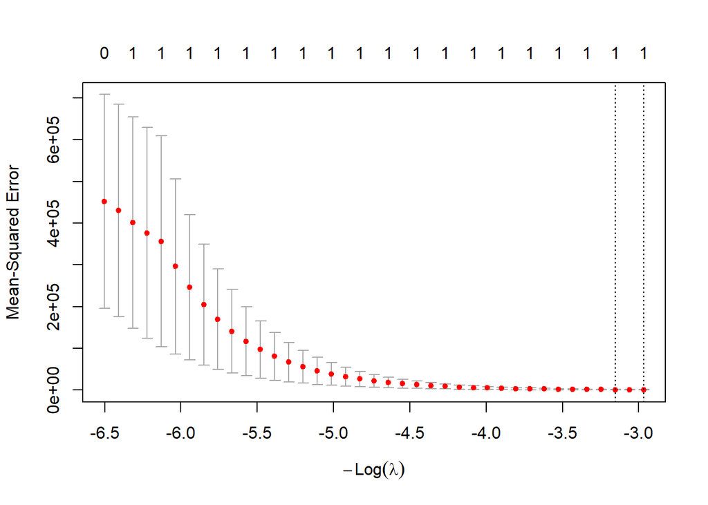

```r
x2 <- model.matrix(Y2 ~ ., data = data2)[,-1]
y2 <- data2$Y2

grid2 <- 10^seq(10, -2, length = 100)

lasso.mod2 = glmnet(x2, y2, alpha = 1, lambda = grid)

cv.out2 <- cv.glmnet(x2, y2, alpha = 1)

plot(cv.out2)
```

```r
bestlam2 <- cv.out2$lambda.min

bestlam2
```

```
## [1] 19.43597
```

```r
lasso.coef2 <- predict(lasso.mod2, type = "coefficients", s = bestlam2)[1:11,]

lasso.coef2
```

```
## (Intercept)           x         x.2         x.3         x.4         x.5
##    3.312317    0.000000    0.000000    0.000000    0.000000    0.000000
##         x.6         x.7         x.8         x.9        x.10
##    0.000000   10.680092    0.000000    0.000000    0.000000
```